# Data Visualization

Honey, Vuthy, James, Sonya, Mohamed

March 24, 2015

Data Visualization for the IS607 Project No. 2 | CUNY MSDA

Load data

```r
load("Awards.Data.RData")

#View(data.awards)
```

```r
library(tidyr)
library(dplyr)
library(ggplot2)
library(knitr)
#library(grid)
library(gridExtra)
```

## Table 1. Number of times a Best Picture winner was nominated or won another category.

```r
# Create BP, a dataframe showing only Best Picture Winners
BP <- filter(data.awards, category_name == "BEST PICTURE", won == 1)

# Create BP.AlsoNom, a dataframe showing what other categories the Best Picture Winners were NOMINATED for
BP.AlsoNom <- left_join(BP, data.awards, by = "movie_name")
BP.AlsoNom <- filter(BP.AlsoNom, category_name.y != "BEST PICTURE")
BP.AlsoNom <- select(BP.AlsoNom, category_name.y)
BP.AlsoNom <- count(BP.AlsoNom, category_name.y)
BP.AlsoNom <- arrange(BP.AlsoNom, desc(n))

# Create BP.AlsoWon, a dataframe showing what other categories the Best Picture winners WON
data.awards.won <- filter(data.awards, won == 1)

BP.AlsoWon <- left_join(BP, data.awards.won, by = "movie_name")
BP.AlsoWon <- filter(BP.AlsoWon, category_name.y != "BEST PICTURE")
BP.AlsoWon <- select(BP.AlsoWon, category_name.y)
BP.AlsoWon <- count(BP.AlsoWon, category_name.y)
BP.AlsoWon <- arrange(BP.AlsoWon, desc(n))

kable(cbind(BP.AlsoNom, BP.AlsoWon),
      col.names = c("Category Nominations", "Count", "Category Winners", "Count"))
```

| Category Nominations | Count | Category Winners | Count |
| --- | --- | --- | --- |
| WRITING | 80 | DIRECTING | 61 |
| DIRECTING | 78 | WRITING | 56 |
| FILM EDITING | 69 | FILM EDITING | 33 |
| ACTOR – LEADING ROLE | 59 | ART DIRECTION | 27 |
| ACTOR – SUPPORTING ROLE | 55 | ACTOR – LEADING ROLE | 26 |
| CINEMATOGRAPHY | 54 | CINEMATOGRAPHY | 25 |
| MUSIC (SCORING) | 50 | MUSIC (SCORING) | 24 |
| ART DIRECTION | 48 | SOUND | 23 |
| SOUND | 45 | COSTUME DESIGN | 19 |
| ACTRESS – SUPPORTING ROLE | 36 | ACTOR – SUPPORTING ROLE | 15 |
| COSTUME DESIGN | 34 | ACTRESS – SUPPORTING ROLE | 12 |
| ACTRESS – LEADING ROLE | 28 | ACTRESS – LEADING ROLE | 11 |
| MAKEUP | 10 | MUSIC (SONG) | 5 |
| MUSIC (SONG) | 10 | MAKEUP | 4 |
| SOUND EDITING | 7 | VISUAL EFFECTS | 4 |
| VISUAL EFFECTS | 5 | SOUND EDITING | 3 |

## Figure 1. Barchart showing the number of times a Best Picture winner was nominated or won another category.

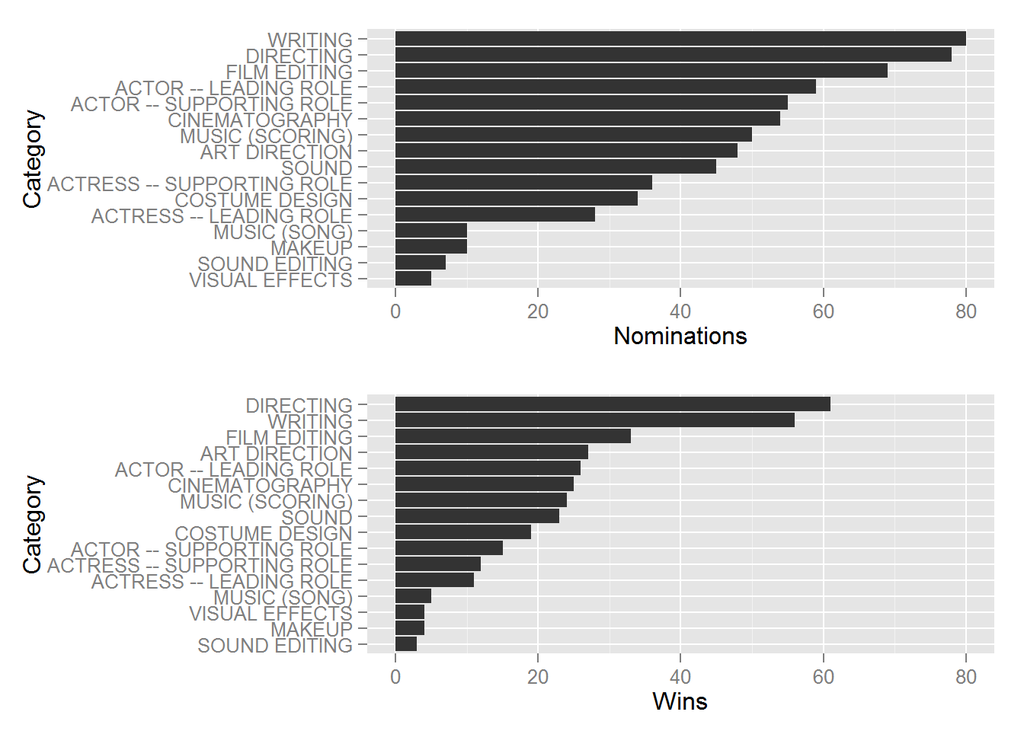

```r
nom <- ggplot(data = BP.AlsoNom, aes(x = reorder(category_name.y, n), y=n)) + geom_bar(stat="identity") + coord_flip() + labs(x = "Category", y = "Nominations")

win <- ggplot(data = BP.AlsoWon, aes(x = reorder(category_name.y, n), y=n)) + geom_bar(stat="identity") + coord_flip() + labs(x = "Category", y = "Wins") + ylim(0, 80)

grid.arrange(nom, win, ncol=1)
```

## Correlation Matrices

Use Sekhar’s method to create award and category matrices

```r
library(dplyr)
library(tidyr)

awards_df <- read.csv("Awards_File.csv",stringsAsFactors=F)
awards_modified <- awards_df[,c(1,3,4,6)]
head(awards_modified)
```

```
##   movie_id year category_id won
## 1        1 2010           1   0
## 2        2 2010           1   0
## 3        2 2010           4   0
## 4        2 2010           6   0
## 5        2 2010           7   0
## 6        2 2010           8   0
```

```r
awards_modified <- awards_modified %>%
  group_by(movie_id,year,category_id) %>%
  summarise(won=max(won))
awards_re_modified <- spread((awards_modified),category_id,won)
head(awards_re_modified)
```

```
## Source: local data frame [6 x 25]
##
##   movie_id year  1  2  3  4  5  6  7  8  9 10 11 12 13 14 15 16 17 18 19
## 1        1 2010  0 NA NA NA NA NA NA NA NA NA NA NA NA NA NA NA NA NA NA
## 2        2 2010  0 NA NA  0 NA  0  0  0  0 NA NA NA NA NA NA  0 NA NA  0
## 3        3 2010  0 NA NA NA NA NA  0 NA  0 NA NA  1 NA  1 NA  0 NA NA  0
## 4        4 2010  1  0 NA  0 NA  0  0  0  1 NA NA  0 NA  0 NA  1 NA NA  0
## 5        5 2010  0 NA NA NA NA NA NA NA NA NA NA  0 NA  0  0  0 NA NA NA
## 6        6 2010 NA  1 NA  1 NA NA NA NA  0 NA NA  0 NA NA NA  0 NA NA NA
## Variables not shown: 20 (int), 21 (int), 22 (int), 23 (int)
```

```r
award_categories <- unique(data.frame(category_id=awards_df$category_id,category_name=awards_df$category_name))
rownames(award_categories) <- NULL
names(awards_re_modified) <- c("movie_id", "year",  "c1",  "c2",  "c3",  "c4",  "c5", "c6",  "c7",  "c8",  "c9", "c10", "c11", "c12", "c13", "c14", "c15","c16", "c17", "c18", "c19", "c20", "c21", "c22", "c23")
```

Modify awards matrix to set NA = 0

```r
####
names(awards_re_modified) <- c("movie_id", "year","ACTOR -- LEADING ROLE","ACTOR -- SUPPORTING ROLE","ACTRESS
LEADING ROLE","ACTRESS SUPPORTING ROLE","ANIMATED FEATURE FILM","ART DIRECTION","CINEMATOGRAPHY","COSTUME
DESIGN","DIRECTING","DOCUMENTARY FEATURE","DOCUMENTARY SHORT SUBJECT","FILM EDITING","MAKEUP","MUSIC
SCORING","MUSIC SONG","BEST PICTURE","SHORT FILM ANIMATED","SHORT FILM LIVE ACTION","SOUND","SOUND
EDITING","VISUAL EFFECTS","WRITING","DOCUMENTARY OTHER")
awards_mod <- awards_re_modified #create new var to preserve original
awards_mod[is.na(awards_mod)] <- 0 #set NA = 0
```

## Figure 2. Correlation matrix, display circles

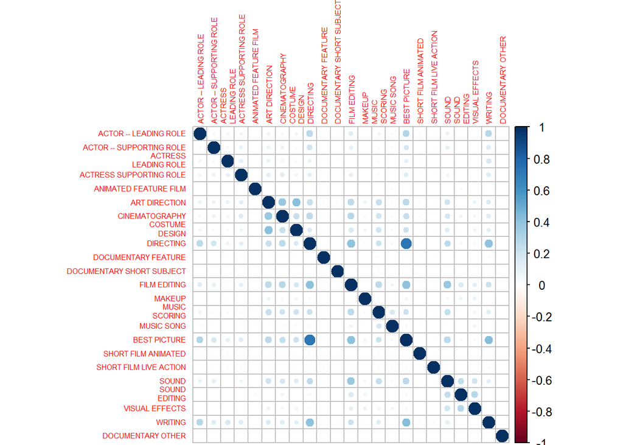

```r
library(corrplot)
W <- cor(awards_mod[3:25]) #correlate c1:c23
corrplot(W, method = "circle", tl.cex = 0.5)
```

## Figure 3. Correlation matrix, display ellipses

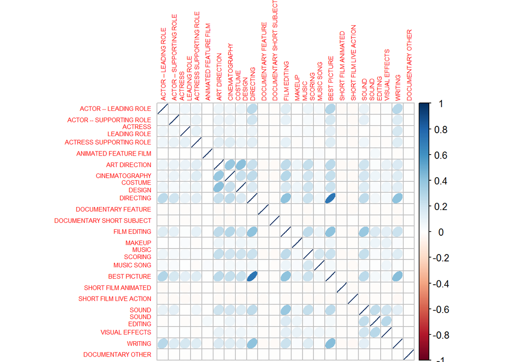

```r
corrplot(W, method = "ellipse", tl.cex = 0.5)
```

## Figure 4. Correlation matrix, display squares

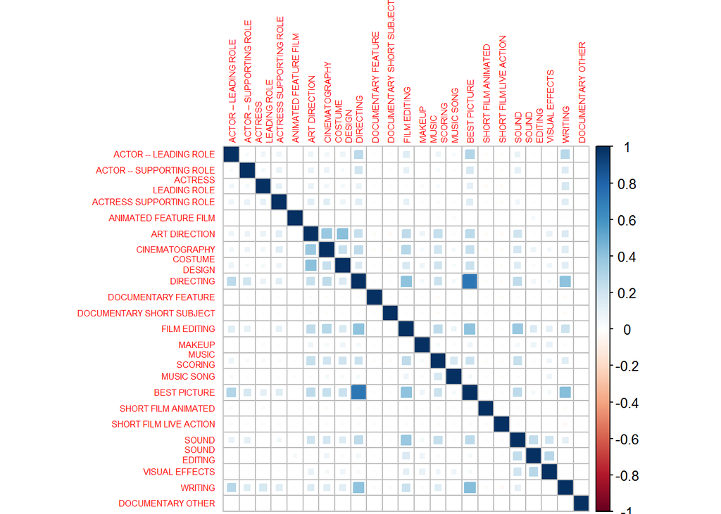

```r
corrplot(W, method = "square", tl.cex = 0.5)
```

## Figure 5. Correlation matrix, using ggplot2

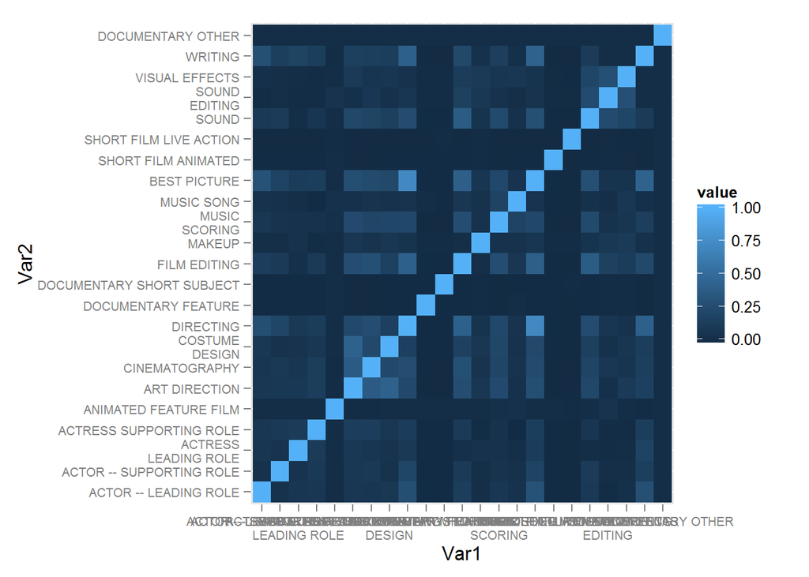

```r
library(ggplot2)
library(reshape2)
cm <- qplot(x=Var1, y=Var2, data=melt(cor(awards_mod[3:25])), fill=value, geom="tile")
cm + theme(axis.text=element_text(size=8))
```

## Table 2. Correlation Matrix, numerical values

```r
x <- awards_mod[3:25]
y <- awards_mod[3:25]
cor(x, y)
```

```
##                           ACTOR -- LEADING ROLE ACTOR -- SUPPORTING ROLE
## ACTOR -- LEADING ROLE               1.000000000              0.031442183
## ACTOR -- SUPPORTING ROLE            0.031442183              1.000000000
## ACTRESS\nLEADING ROLE               0.063755763              0.044702504
## ACTRESS SUPPORTING ROLE             0.069755123              0.090204750
## ANIMATED FEATURE FILM              -0.007796584             -0.007314613
## ART DIRECTION                       0.072506810              0.080054937
## CINEMATOGRAPHY                      0.058936153              0.087843420
## COSTUME\nDESIGN                     0.078686034              0.033580145
## DIRECTING                           0.267328311              0.197464921
## DOCUMENTARY FEATURE                -0.018964075             -0.017791749
## DOCUMENTARY SHORT SUBJECT          -0.018825820             -0.017662041
## FILM EDITING                        0.131378762              0.101967154
## MAKEUP                              0.007197662              0.009224239
## MUSIC\nSCORING                      0.074022300              0.039563592
## MUSIC SONG                          0.030521724              0.021538257
## BEST PICTURE                        0.295265477              0.174406734
## SHORT FILM ANIMATED                -0.020168626             -0.018921837
## SHORT FILM LIVE ACTION             -0.023553485             -0.022097450
## SOUND                               0.091877626              0.113451180
## SOUND\nEDITING                     -0.013917970              0.005933184
## VISUAL EFFECTS                      0.016160545              0.002224411
## WRITING                             0.272537746              0.141419198
## DOCUMENTARY OTHER                  -0.004497010             -0.004219012
##                           ACTRESS\nLEADING ROLE ACTRESS SUPPORTING ROLE
## ACTOR -- LEADING ROLE              0.0637557625             0.069755123
## ACTOR -- SUPPORTING ROLE           0.0447025037             0.090204750
## ACTRESS\nLEADING ROLE              1.0000000000             0.108928458
## ACTRESS SUPPORTING ROLE            0.1089284579             1.000000000
## ANIMATED FEATURE FILM             -0.0077496318            -0.007314613
## ART DIRECTION                      0.0839561720             0.125503007
## CINEMATOGRAPHY                     0.0595665577             0.132112232
## COSTUME\nDESIGN                    0.0420486161             0.073047923
## DIRECTING                          0.0879173749             0.120839042
## DOCUMENTARY FEATURE               -0.0188498701            -0.017791749
## DOCUMENTARY SHORT SUBJECT         -0.0187124480            -0.017662041
## FILM EDITING                       0.0182542530             0.101967154
## MAKEUP                             0.0272607454            -0.011783712
## MUSIC\nSCORING                     0.0347082404             0.028980108
## MUSIC SONG                         0.0055738644            -0.018676191
```

[output cut: 185 more lines]

```
## DIRECTING                      -0.004497010
## DOCUMENTARY FEATURE            -0.004073452
## DOCUMENTARY SHORT SUBJECT      -0.004043755
## FILM EDITING                   -0.004275947
## MAKEUP                         -0.002697901
## MUSIC\nSCORING                 -0.005480490
## MUSIC SONG                     -0.004275947
## BEST PICTURE                   -0.004442695
## SHORT FILM ANIMATED            -0.004332187
## SHORT FILM LIVE ACTION         -0.005059250
## SOUND                          -0.004332187
## SOUND\nEDITING                 -0.002989557
## VISUAL EFFECTS                 -0.003364070
## WRITING                        -0.006564145
## DOCUMENTARY OTHER               1.000000000
```

*An analysis of the various correlation matrix visualizations and table of numerical values shows the primary determining factor is DIRECTING, followed by WRITING and then FILM EDITING.*

Note: There was an issue with NA values; we could not get them to be ignored, so instead had to set them equal to 0, which may have resulted in some skewing of the results.

```r
require(ggplot2)
library(ggplot2)
library(plot3D)
library(scatterplot3d)
```

I took the summary table that Honey, Vuthy, James, and Sonya had created and added few graphics as well

Please note that i only took the summary with the below following columns: Category.Nominations, Count, Category.Winners, Count

Also, I loaded and shared the table as csv using dropconvas website as per below

```r
data1<- read.table(file= "http://dropcanvas.com/dcm0h/1", header = TRUE, sep=",")
str(data1)
```

```
## 'data.frame':    16 obs. of  4 variables:
##  $ Category.Nominations: Factor w/ 16 levels "ACTOR  LEADING ROLE",..: 16 8 9 1 2 6 11 5 13 4 ...
##  $ Count               : int  80 78 69 59 55 54 50 48 45 36 ...
##  $ Category.Winners    : Factor w/ 16 levels "ACTOR  LEADING ROLE",..: 8 16 9 5 1 6 11 13 7 2 ...
##  $ Count.1             : int  61 56 33 27 26 25 24 23 19 15 ...
```

```r
head(data1)
```

```
##      Category.Nominations Count     Category.Winners Count.1
## 1                 WRITING    80            DIRECTING      61
## 2               DIRECTING    78              WRITING      56
## 3            FILM EDITING    69         FILM EDITING      33
## 4    ACTOR  LEADING ROLE    59        ART DIRECTION      27
## 5 ACTOR  SUPPORTING ROLE    55 ACTOR  LEADING ROLE      26
## 6          CINEMATOGRAPHY    54       CINEMATOGRAPHY      25
```

# Distribution Nominations By Category

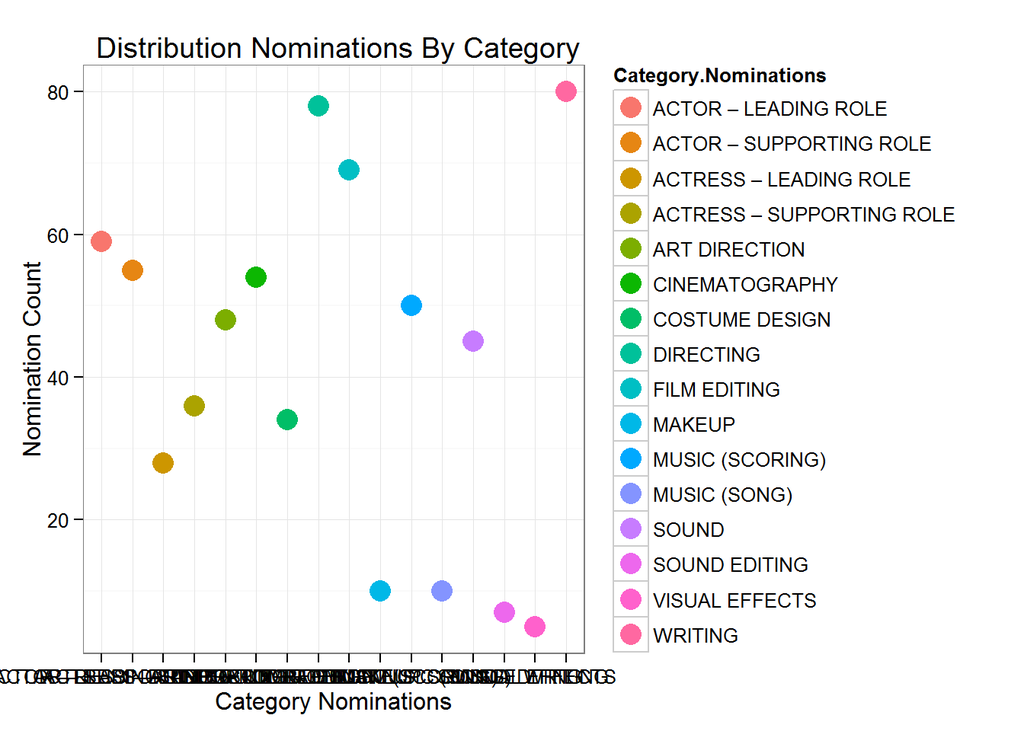

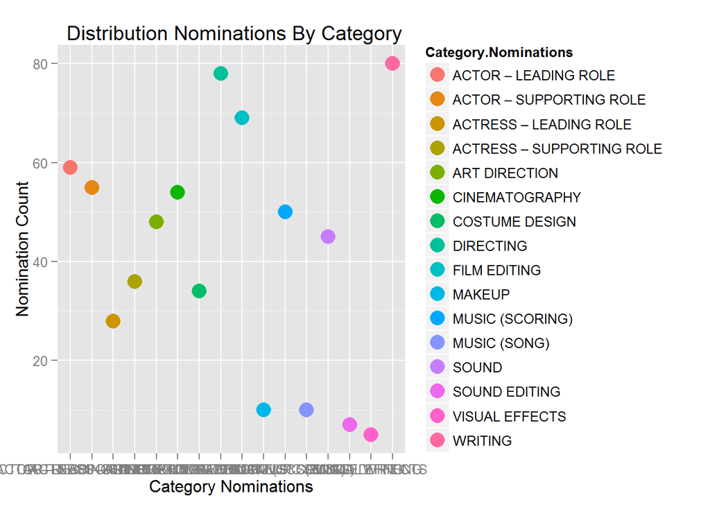

# Distribution of Winning By Category

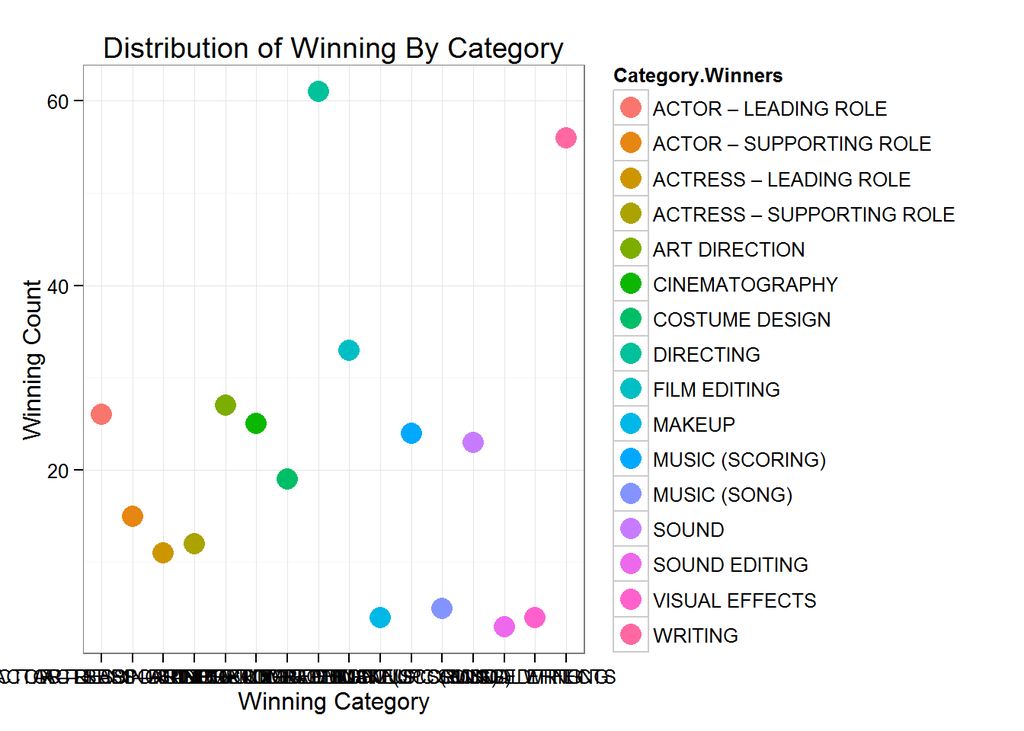

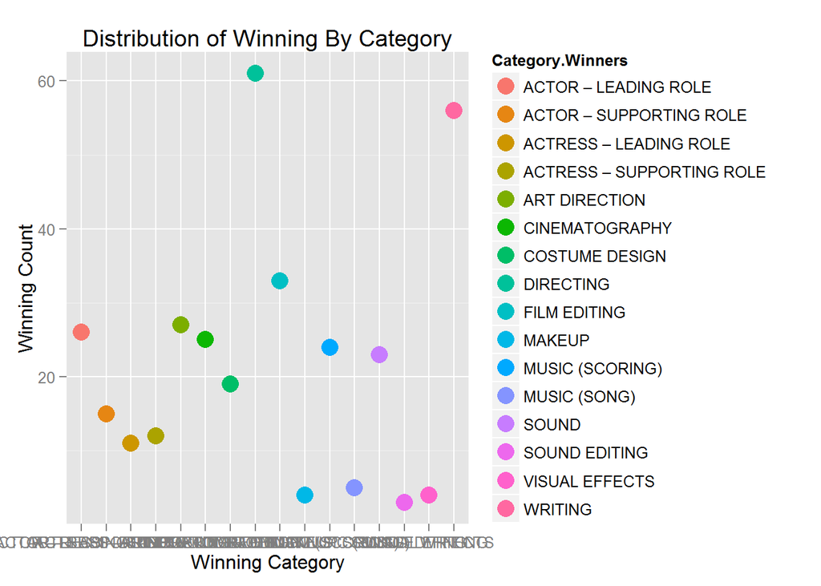

# Distribution of Wins over Winning by Nominations Category

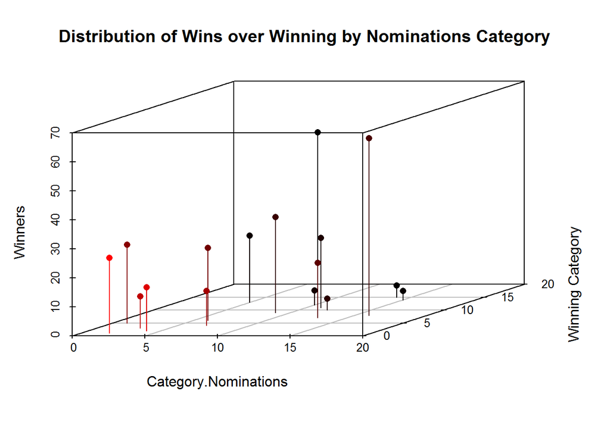

```r
attach(data1)
scatterplot3d(Category.Nominations, Category.Winners, Count.1, pch=16, highlight.3d=TRUE,
               type="h", main="Distribution of Wins over Winning by Nominations Category",
               xlab = "Category.Nominations", ylab = "Winning Category", zlab = " Winners")
```